# Global Birth Trends: A World in Transition

A UNICEF Data Story on Birth Rates Across the Globe

Author

Dhruv Kadam

Published

April 14, 2026

228Countries Tracked

1950-2023Years of Data

73 yrsHistorical Span

## Introduction

Every child born into this world represents a story of hope, potential, and the continuation of humanity. The number of births in a country is one of the most fundamental indicators of its demographic health, shaping its economy, workforce, and social fabric for generations to come.

This report explores a key UNICEF indicator:

> *The number of births recorded across 228 countries from 1950 to 2023, measured in thousands of persons.*

Understanding birth trends matters because:

- **Population growth** drives demand for schools, hospitals, and infrastructure
- **Declining birth rates** signal aging populations and future workforce shortages
- **Regional disparities** reveal stark differences in development and health outcomes
- **Historical patterns** help governments plan for the future with greater accuracy

The data tells a compelling story of a world in demographic transition — where some regions are experiencing rapid population growth while others face the challenge of shrinking populations.

## Data Preparation

This section loads and transforms the UNICEF birth data and metadata files using **polars**. The datasets are merged on the ISO country code to enable richer analysis combining birth numbers with economic indicators.

```python
import polars as pl
import pandas as pd
import numpy as np
import geopandas as gpd
from plotnine import *
import matplotlib
matplotlib.use("Agg")
import matplotlib.pyplot as plt
from IPython.display import display, HTML, Image as IPImage
import warnings
warnings.filterwarnings("ignore")

# Load both files using polars
indicator_raw = pl.read_csv("unicef_indicator_2.csv")
metadata_raw  = pl.read_csv("unicef_metadata.csv")

# Filter to Total sex only
indicator_total = indicator_raw.filter(pl.col("sex") == "Total")

# Get latest year value per country
latest_pl = (
    indicator_total
    .sort("time_period", descending=True)
    .unique(subset=["country"], keep="first")
)

# Get most recent metadata per country
meta_pl = (
    metadata_raw
    .sort("year", descending=True)
    .unique(subset=["country"], keep="first")
)

# Join on 3-letter country code
merged_pl = latest_pl.join(meta_pl, on="alpha_3_code", how="left")
latest    = latest_pl.to_pandas()
merged    = merged_pl.to_pandas()

# EDA summary
n_countries   = indicator_total.select("country").n_unique()
latest_year   = int(indicator_total["time_period"].max())
earliest_year = int(indicator_total["time_period"].min())
total_births  = round(float(
    indicator_total
    .filter(pl.col("time_period") == latest_year)
    .select("obs_value").sum()[0, 0]
), 1)
max_country = latest_pl.sort("obs_value", descending=True).head(1)["country"][0]

summary_df = pd.DataFrame({
    "Metric": ["Countries tracked", "Earliest year", "Latest year",
               "Total global births latest year (thousands)",
               "Country with most births"],
    "Value":  [str(n_countries), str(earliest_year), str(latest_year),
               f"{total_births:,.1f}", max_country]
})
print(summary_df.to_string(index=False))
```

```
                                     Metric     Value
                          Countries tracked       228
                              Earliest year      1950
                                Latest year      2023
Total global births latest year (thousands) 132,076.8
                   Country with most births     India
```

EDA Finding

The dataset spans **73 years** of birth data across **228 countries**. Global births have grown significantly since 1950, though the rate of growth has slowed in recent decades as fertility rates decline across many parts of the world.

## Visualisation 1 - World Map

The map below shows the **latest recorded number of births** for each country. Darker shades indicate higher birth numbers, revealing where the world’s new generations are being born.

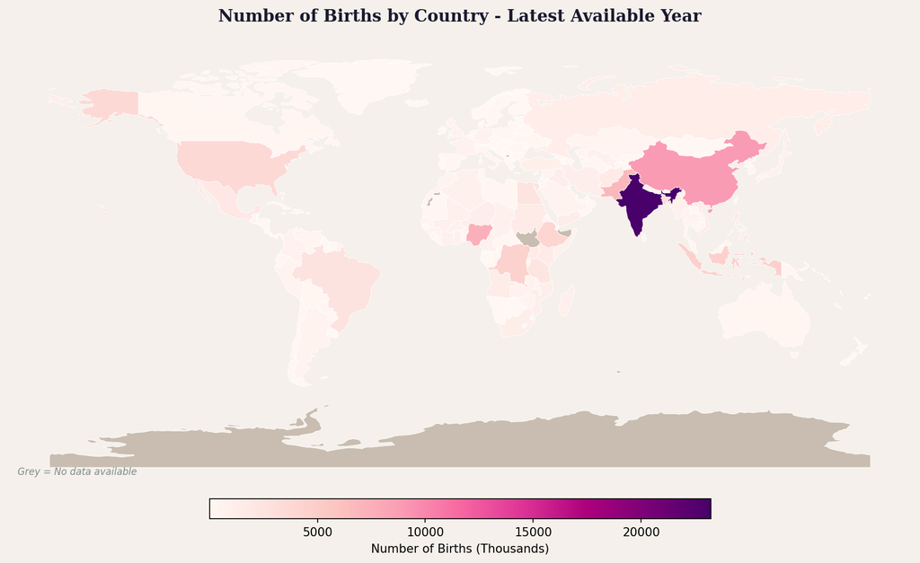

Figure 1: Figure 1: Number of births by country, latest available year (in thousands). Source: UNICEF

```python
world    = gpd.read_file("countries.geojson")
world    = world.rename(columns={"ADM0_A3": "alpha_3_code"})
map_data = world.merge(latest[["alpha_3_code", "obs_value"]],
                       on="alpha_3_code", how="left")

fig, ax = plt.subplots(figsize=(15, 7))
fig.patch.set_facecolor("#f5f0eb")
ax.set_facecolor("#e8e0d8")

map_data[map_data["obs_value"].isna()].plot(
    ax=ax, color="#c8bdb0", edgecolor="white", linewidth=0.4)
map_data[map_data["obs_value"].notna()].plot(
    column="obs_value", ax=ax, cmap="RdPu",
    edgecolor="white", linewidth=0.4, legend=True,
    legend_kwds={"label": "Number of Births (Thousands)",
                 "orientation": "horizontal",
                 "shrink": 0.4, "pad": 0.02, "aspect": 25})

ax.set_title("Number of Births by Country - Latest Available Year",
             fontsize=14, fontweight="bold", pad=15, color="#1a1a2e",
             fontfamily="serif")
ax.annotate("Grey = No data available", xy=(0.01, 0.03),
            xycoords="axes fraction", fontsize=8,
            color="#7f8c8d", fontstyle="italic")
ax.axis("off")
fig.tight_layout()
plt.savefig("worldmap.png", dpi=150, bbox_inches="tight", facecolor="#f5f0eb")
plt.close()
display(IPImage("worldmap.png"))
```

Geographic Insight

**Asia and Africa** dominate global birth numbers, with countries like India, China, and Nigeria recording the highest totals. In contrast, most European and high-income countries show significantly lower birth numbers, reflecting decades of declining fertility rates and aging populations.

## Visualisation 2 - Country Rankings

The chart below compares the **top 15 and bottom 15 countries** by their latest recorded birth numbers, revealing the enormous gap in population dynamics across the world.

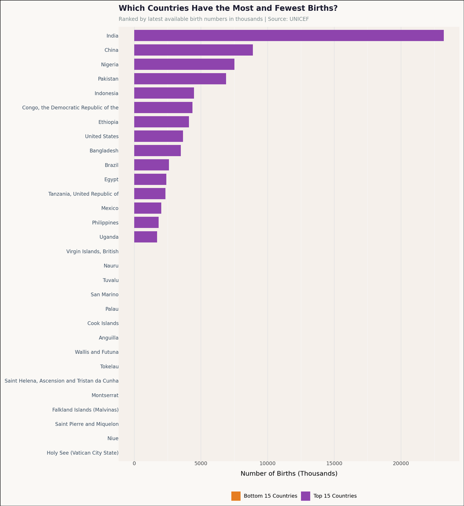

Figure 2: Figure 2: Top 15 and bottom 15 countries by number of births, latest year. Source: UNICEF

```python
top15 = (latest_pl.sort("obs_value", descending=True).head(15)
         .with_columns(pl.lit("Top 15 Countries").alias("group")))
bot15 = (latest_pl.sort("obs_value", descending=False).head(15)
         .with_columns(pl.lit("Bottom 15 Countries").alias("group")))

bar_df = (pl.concat([top15, bot15]).to_pandas()
          .sort_values("obs_value", ascending=True))
bar_df["country_label"] = bar_df["country"]

(
    ggplot(bar_df, aes(x="reorder(country_label, obs_value)",
                       y="obs_value", fill="group"))
    + geom_col(width=0.78)
    + coord_flip()
    + scale_fill_manual(values={"Top 15 Countries": "#8e44ad",
                                "Bottom 15 Countries": "#e67e22"})
    + labs(title="Which Countries Have the Most and Fewest Births?",
           subtitle="Ranked by latest available birth numbers in thousands | Source: UNICEF",
           x="", y="Number of Births (Thousands)", fill="")
    + theme_minimal()
    + theme(figure_size=(11, 12),
            plot_title=element_text(size=13, weight="bold", color="#1a1a2e"),
            plot_subtitle=element_text(size=9, color="#7f8c8d"),
            axis_text_y=element_text(size=8.5, color="#3d4f61"),
            legend_position="bottom",
            panel_grid_major_y=element_blank(),
            plot_background=element_rect(fill="#faf8f5", color=None),
            panel_background=element_rect(fill="#f5f0eb", color=None))
)
```

## Visualisation 3 - Does Wealth Affect Birth Numbers?

The scatterplot compares each country’s birth numbers against its **GDP per capita** on a log scale, exploring whether economic development is linked to birth rates.

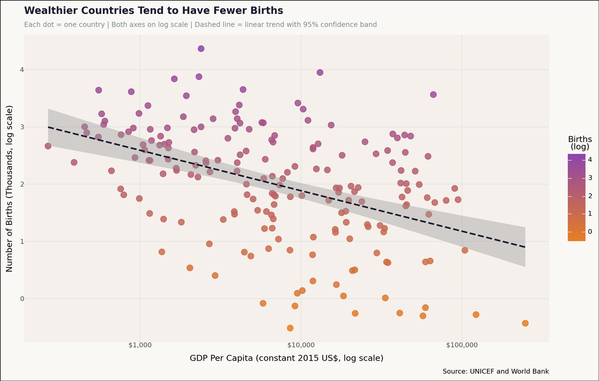

Figure 3: Figure 3: GDP per capita vs number of births. Source: UNICEF and World Bank

```python
gdp_col    = "GDP per capita (constant 2015 US$)"
scatter_pl = merged_pl.filter(
    pl.col(gdp_col).is_not_null() & pl.col("obs_value").is_not_null())
scatter_df = scatter_pl.to_pandas()
scatter_df["log_gdp"]    = np.log10(scatter_df[gdp_col])
scatter_df["log_births"] = np.log10(scatter_df["obs_value"].clip(lower=0.01))

for col in ["country_right", "country_x", "country"]:
    if col in scatter_df.columns:
        scatter_df["country_label"] = scatter_df[col]
        break

(
    ggplot(scatter_df, aes(x="log_gdp", y="log_births"))
    + geom_point(aes(color="log_births"), size=4, alpha=0.85)
    + geom_smooth(method="lm", color="#1a1a2e", se=True,
                  size=1.2, linetype="dashed")
    + scale_color_gradient(low="#e67e22", high="#8e44ad", name="Births\n(log)")
    + scale_x_continuous(breaks=[2, 3, 4, 5],
                         labels=["$100", "$1,000", "$10,000", "$100,000"])
    + labs(title="Wealthier Countries Tend to Have Fewer Births",
           subtitle="Each dot = one country | Both axes on log scale | Dashed line = linear trend with 95% confidence band",
           x="GDP Per Capita (constant 2015 US$, log scale)",
           y="Number of Births (Thousands, log scale)",
           caption="Source: UNICEF and World Bank")
    + theme_minimal()
    + theme(figure_size=(11, 7),
            plot_title=element_text(size=13, weight="bold", color="#1a1a2e"),
            plot_subtitle=element_text(size=9, color="#7f8c8d"),
            panel_grid_minor=element_blank(),
            plot_background=element_rect(fill="#faf8f5", color=None),
            panel_background=element_rect(fill="#f5f0eb", color=None))
)
```

## Visualisation 4 - Trends Over Time

The final chart tracks how birth numbers have **changed across decades** for selected major countries, revealing the dramatic demographic shifts that have occurred since 1950.

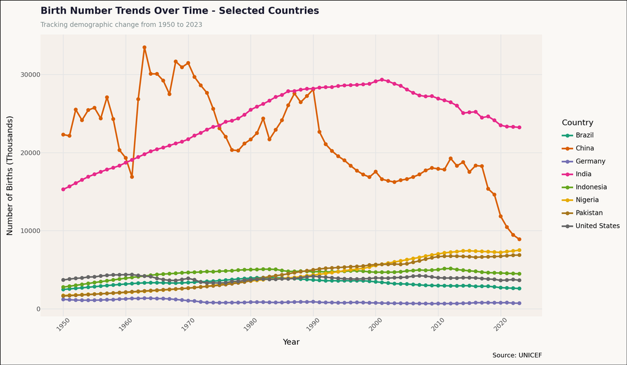

Figure 4: Figure 4: Birth number trends over time for selected countries. Source: UNICEF

```python
selected_countries = ["India", "China", "Nigeria", "United States",
                      "Brazil", "Pakistan", "Indonesia", "Germany"]

ts_df = (
    indicator_total
    .filter(pl.col("country").is_in(selected_countries))
    .group_by(["country", "time_period"])
    .agg(pl.col("obs_value").mean().alias("obs_value"))
    .sort(["country", "time_period"])
    .to_pandas()
)

ts_df = ts_df[ts_df["country"].isin(selected_countries)]

(
    ggplot(ts_df, aes(x="time_period", y="obs_value",
                      color="country", group="country"))
    + geom_line(size=1.2)
    + geom_point(size=2)
    + scale_x_continuous(breaks=[1950, 1960, 1970, 1980, 1990, 2000, 2010, 2020])
    + scale_color_brewer(type="qual", palette="Dark2", name="Country")
    + labs(title="Birth Number Trends Over Time - Selected Countries",
           subtitle="Tracking demographic change from 1950 to 2023",
           x="Year",
           y="Number of Births (Thousands)",
           caption="Source: UNICEF")
    + theme_minimal()
    + theme(figure_size=(12, 7),
            plot_title=element_text(size=13, weight="bold", color="#1a1a2e"),
            plot_subtitle=element_text(size=9, color="#7f8c8d"),
            legend_position="right",
            legend_text=element_text(size=9),
            axis_text_x=element_text(angle=45),
            panel_grid_minor=element_blank(),
            plot_background=element_rect(fill="#faf8f5", color=None),
            panel_background=element_rect(fill="#f5f0eb", color=None))
)
```

## Conclusion

This analysis of global birth trends reveals a world undergoing profound demographic transformation.

Asia and Africa Lead Growth

The majority of the world's births occur in Asia and Africa. India, Nigeria, and Pakistan are driving global population growth into the 21st century.

Wealth Reduces Fertility

As countries develop economically, birth rates tend to fall. This demographic transition is visible across Europe, East Asia, and Latin America.

Policy Shapes Demographics

China's one-child policy demonstrates how government intervention can dramatically alter birth trends. Policy decisions have generational consequences.

Planning Is Essential

Understanding birth trends is critical for planning education, healthcare, housing, and pension systems. Governments must act on demographic data today.

> *Every birth is a beginning. Understanding where and how many children are being born is essential for building a world that is ready to nurture and support them all.*

The story of global births is ultimately a story of hope, challenge, and the responsibility that falls on every generation to prepare a better world for the next.

*Report prepared using UNICEF open data. Data transformations with polars. Visualisations with plotnine in Python.*